# Fraud Detection - Group 3

Cindy Gachuhi, Karen Mwaura, Joseph Kiburu, Kipsang Mutai & Kelvin Kilel

2/8/2022

# Defining the question.

Fraud is constantly evolving at very high rates. The world is adopting digital technology. While this is a good thing for companies and financial institutions, it also comes with its downside, the likes of cyber hacking, identity theft and insurance scams. Hence, companies are adopting new solutions to respond to the online threats that come with going digital.

Fraud detection plays a part in reducing the number of fraud cases. Fraud detection is a set of activities undertaken to prevent money or property from being obtained through false pretences. Fraud in banks would include activities like forging cheques or using a stolen credit/ debit card.

Banks can incorporate fraud detection into their websites, company policies, employee training, and enhanced security features.

Fraud has been rampant among financial institutions in which the majority end up having more liabilities than assets. Due to fraud, people may also lack faith in the institutions. It’s eroding the profitability of businesses with disturbing effects on firm solvency.

# Objective

### overall Objective Identify potential fraud transactions as a result of analysing customer behaviour regarding the amount and type of transactions made over a period of time.

### Specific objectives: *How many transactions are fraudulent?* *What types of transactions correspond with fraud?* *What types of transactions are flagged as fraudulent?* *What does the distribution of transaction amount look like for fraudulent cases?* *Does fraud occur more often at a certain time of day?*

# Data sourcing

The dataset is from kaggle and the link is https://www.kaggle.com/gopalmahadevan/fraud-detection-example?select=fraud_dataset_example.csv

# Experimental design

To conduct a thorough analysis of our variables and apply various supervised and unsupervised learning models to train our data into giving accurate predictions on whether transactions are fraudulent or otherwise.

# Defining the metrics of success

.Predicting fraud detection in order to reduce fraudulent activities online.

.Providing a good model with an accuracy of 80-95%.

# Description of the dataset columns.

The following is a description of the various columns contained in the dataset above:

*step* - unit of time (1 hour)

*type* - CASH-IN, CASH-OUT, DEBIT, PAYMENT and TRANSFER.

*amount* - transaction amount in local currency.

*nameOrig* - transaction originator

*oldbalanceOrg* - initial balance (before transaction)

*newbalanceOrig* - new balance (after transaction)

*nameDest* - transaction recipient

*oldbalanceDest* - initial balance before transaction.

*newbalanceDest* - new balance after transaction.

*isFraud* - A fraud agent takes control of customers’ accounts and attempts to empty them by transferring their money to another account and then cashing out.

*isFlaggedFraud* - An illegal attempt to transfer a massive amount of money in a single transaction.

# Reading the Dataset

```r
#install.packages('ggpubr')
```

```r
# Loading the Required Libraries

# data.table::update.dev.pkg()
library(data.table)
library(tidyverse)
library(psych)
```

```r
library(ggpubr)
library(corrplot)
# Loading the dataset

df <- read.csv("D:/C++/fraud_dataset_example.csv")
```

```r
# Previewing the top records
head(df)
```

```
##   step     type   amount    nameOrig oldbalanceOrg newbalanceOrig    nameDest
## 1    1  PAYMENT  9839.64 C1231006815        170136      160296.36 M1979787155
## 2    1  PAYMENT  1864.28 C1666544295         21249       19384.72 M2044282225
## 3    1 TRANSFER   181.00 C1305486145           181           0.00  C553264065
## 4    1 CASH_OUT   181.00  C840083671           181           0.00   C38997010
## 5    1  PAYMENT 11668.14 C2048537720         41554       29885.86 M1230701703
## 6    1  PAYMENT  7817.71   C90045638         53860       46042.29  M573487274
##   oldbalanceDest newbalanceDest isFraud isFlaggedFraud
## 1              0              0       0              0
## 2              0              0       0              0
## 3              0              0       1              0
## 4          21182              0       1              0
## 5              0              0       0              0
## 6              0              0       0              0
```

```r
summary(df)
```

```
##       step            type               amount           nameOrig
##  Min.   : 1.000   Length:101613      Min.   :       0   Length:101613
##  1st Qu.: 8.000   Class :character   1st Qu.:   10017   Class :character
##  Median : 9.000   Mode  :character   Median :   53385   Mode  :character
##  Mean   : 8.523                      Mean   :  174090
##  3rd Qu.:10.000                      3rd Qu.:  212498
##  Max.   :10.000                      Max.   :10000000
##  oldbalanceOrg      newbalanceOrig       nameDest         oldbalanceDest
##  Min.   :       0   Min.   :       0   Length:101613      Min.   :       0
##  1st Qu.:       0   1st Qu.:       0   Class :character   1st Qu.:       0
##  Median :   20190   Median :       0   Mode  :character   Median :   21058
##  Mean   :  907178   Mean   :  923501                      Mean   :  881048
##  3rd Qu.:  194715   3rd Qu.:  219218                      3rd Qu.:  591922
##  Max.   :38900000   Max.   :38900000                      Max.   :34000000
##  newbalanceDest        isFraud         isFlaggedFraud
##  Min.   :       0   Min.   :0.000000   Min.   :0
##  1st Qu.:       0   1st Qu.:0.000000   1st Qu.:0
##  Median :   51783   Median :0.000000   Median :0
##  Mean   : 1184036   Mean   :0.001142   Mean   :0
##  3rd Qu.: 1063122   3rd Qu.:0.000000   3rd Qu.:0
##  Max.   :38900000   Max.   :1.000000   Max.   :0
```

```r
# Checking the data types
str(df)
```

```
## 'data.frame':    101613 obs. of  11 variables:
##  $ step          : int  1 1 1 1 1 1 1 1 1 1 ...
##  $ type          : chr  "PAYMENT" "PAYMENT" "TRANSFER" "CASH_OUT" ...
##  $ amount        : num  9840 1864 181 181 11668 ...
##  $ nameOrig      : chr  "C1231006815" "C1666544295" "C1305486145" "C840083671" ...
##  $ oldbalanceOrg : num  170136 21249 181 181 41554 ...
##  $ newbalanceOrig: num  160296 19385 0 0 29886 ...
##  $ nameDest      : chr  "M1979787155" "M2044282225" "C553264065" "C38997010" ...
##  $ oldbalanceDest: num  0 0 0 21182 0 ...
##  $ newbalanceDest: num  0 0 0 0 0 ...
##  $ isFraud       : int  0 0 1 1 0 0 0 0 0 0 ...
##  $ isFlaggedFraud: int  0 0 0 0 0 0 0 0 0 0 ...
```

# Tidying the Dataset

```r
# Checking for missing values
colSums(is.na(df))
```

```
##           step           type         amount       nameOrig  oldbalanceOrg
##              0              0              0              0              0
## newbalanceOrig       nameDest oldbalanceDest newbalanceDest        isFraud
##              0              0              0              0              0
## isFlaggedFraud
##              0
```

```r
# There are no missing values in our dataset.
```

*There are no missing values in our dataset.*

```r
# Converting the data to a table

df1 <- data.frame(df)
```

```r
# Converting column names to lower case for uniformity

colnames(df1) <- tolower(colnames(df1))

# Confirming the changes
head(df1)
```

```
##   step     type   amount    nameorig oldbalanceorg newbalanceorig    namedest
## 1    1  PAYMENT  9839.64 C1231006815        170136      160296.36 M1979787155
## 2    1  PAYMENT  1864.28 C1666544295         21249       19384.72 M2044282225
## 3    1 TRANSFER   181.00 C1305486145           181           0.00  C553264065
## 4    1 CASH_OUT   181.00  C840083671           181           0.00   C38997010
## 5    1  PAYMENT 11668.14 C2048537720         41554       29885.86 M1230701703
## 6    1  PAYMENT  7817.71   C90045638         53860       46042.29  M573487274
##   oldbalancedest newbalancedest isfraud isflaggedfraud
## 1              0              0       0              0
## 2              0              0       0              0
## 3              0              0       1              0
## 4          21182              0       1              0
## 5              0              0       0              0
## 6              0              0       0              0
```

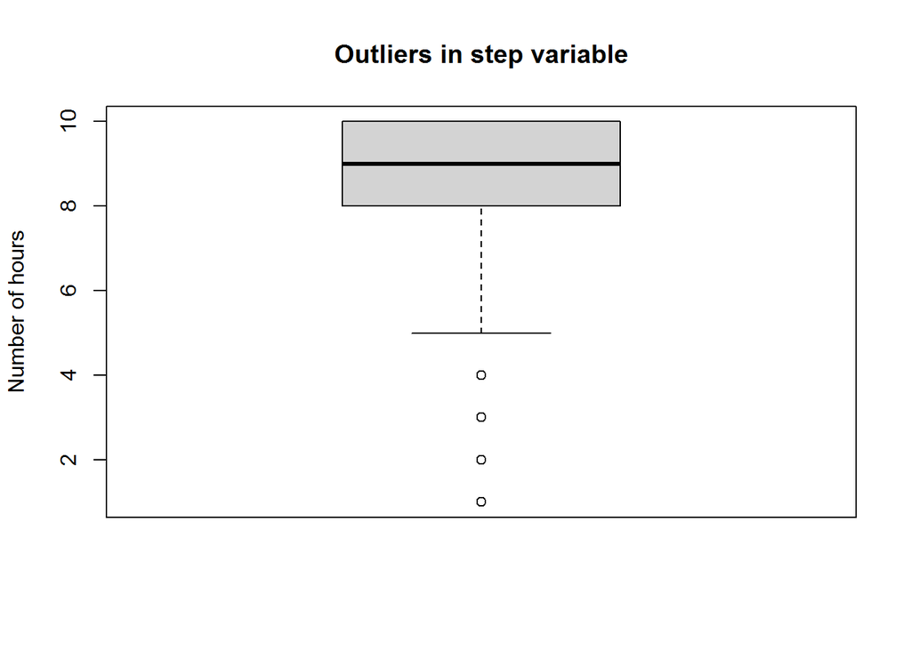

```r
# Checking for outliers
## Identifying the numerical columns

#numcols <- subset(df1, select = -c( type, nameorig, namedest,isfraud, isflaggedfraud))

#head(numcols)

# Checking for outliers using boxplot
#boxplot(numcols)
boxplot(df1$step,
        main = "Outliers in step variable",
        ylab = "Number of hours")
```

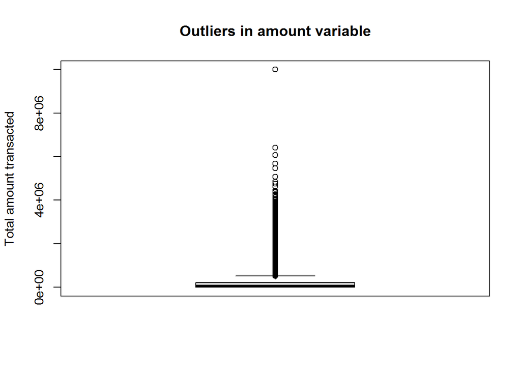

```r
boxplot(df1$amount,
        main = "Outliers in amount variable",
        ylab = "Total amount transacted")
```

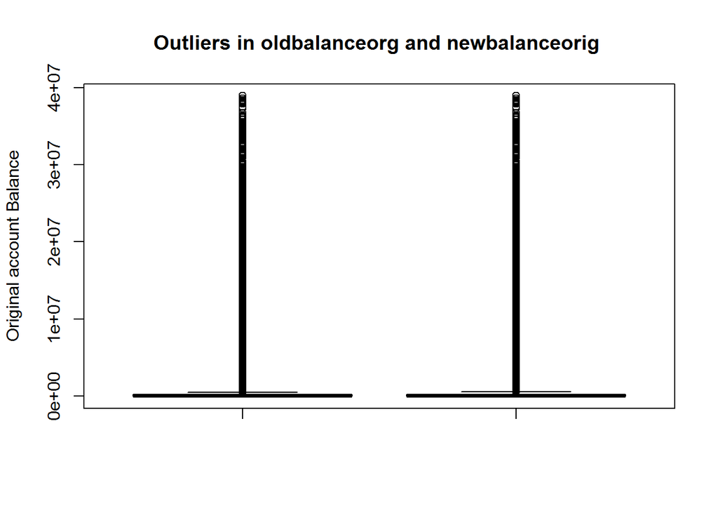

```r
boxplot(df1$oldbalanceorg, df1$newbalanceorig,
        main = "Outliers in oldbalanceorg and newbalanceorig ",
        ylab = "Original account Balance")
```

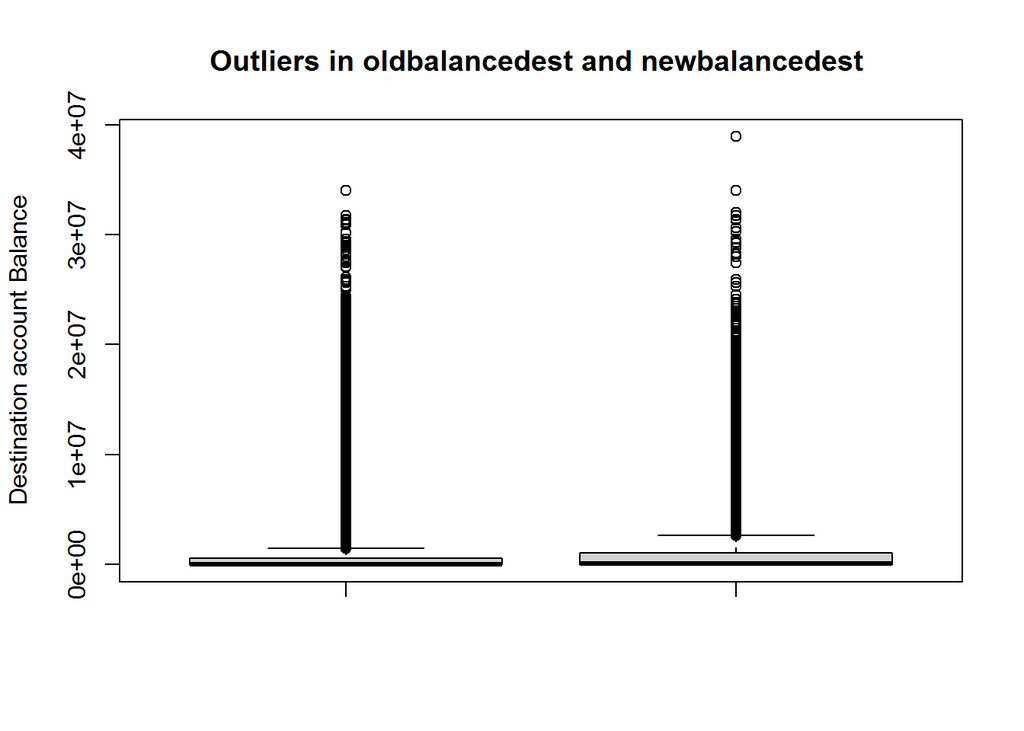

```r
boxplot(df1$oldbalancedest, df1$newbalancedest,
        main = "Outliers in oldbalancedest and newbalancedest ",
        ylab = "Destination account Balance")
```

The numerical columns in our dataset consist of amount transferred, new balances and old balances. The outliers are expected because we have different people doing transactions from different income levels. Since the outliers also form large part of our dataset, dropping them will leave us with a small amount of data to work with.

# Univariate Analysis

## Central Tendecies

```r
numcols <- subset(df1, select = -c( type, nameorig, namedest,isfraud, isflaggedfraud))
describe(numcols)
```

```
##                vars      n       mean         sd   median   trimmed      mad
## step              1 101613       8.52       1.82     9.00      8.88     1.48
## amount            2 101613  174090.07  345019.90 53385.41 102694.86 74440.34
## oldbalanceorg     3 101613  907177.81 2829599.19 20190.47 178716.07 29934.39
## newbalanceorig    4 101613  923501.45 2867332.58     0.00 181210.43     0.00
## oldbalancedest    5 101613  881047.57 2399986.52 21058.00 300302.15 31220.59
## newbalancedest    6 101613 1184036.37 2797923.75 51783.43 491938.61 76774.11
##                 min      max    range  skew kurtosis      se
## step           1.00       10        9 -2.55     7.40    0.01
## amount         0.32 10000000 10000000  5.43    47.82 1082.35
## oldbalanceorg  0.00 38900000 38900000  5.29    36.91 8876.67
## newbalanceorig 0.00 38900000 38900000  5.22    35.93 8995.05
## oldbalancedest 0.00 34000000 34000000  5.06    32.52 7528.95
## newbalancedest 0.00 38900000 38900000  4.32    23.96 8777.31
```

The mean time where the transactions occurred is between hour 8 to 9.

The average transaction amount is 174,090.07 while the maximum transacted amount is 10,000,000.

Apart from Step variable, all the other columns have positive skewness.

All our variables are leptokurtic because there kurtosis value is greater than 3. A high kurtosis means a heavy tail which indicates the presence of outliers while a low kurtosis means a light tail hence no outliers. A kurtosis greater than +1 indicates that the distribution is too peaked.(High kurtosis) while a kurtosis lower than -1 indicates a distribution that is too flat. Both of these parameters indicate that the distribution is not normal.

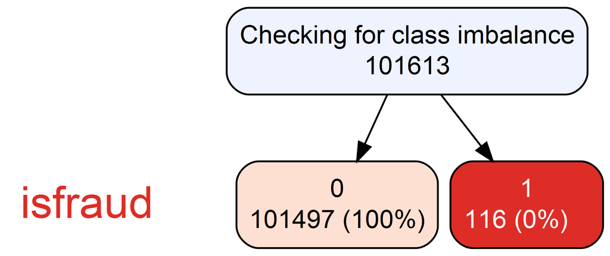

```r
# checking for Class Imbalance using vtree
library(vtree)

vtree(df1,"isfraud", title="Checking for class imbalance",horiz=FALSE)
```

Clearly, we can see that we have a class imbalance from the above diagram.

# Graphical Univariate Analysis

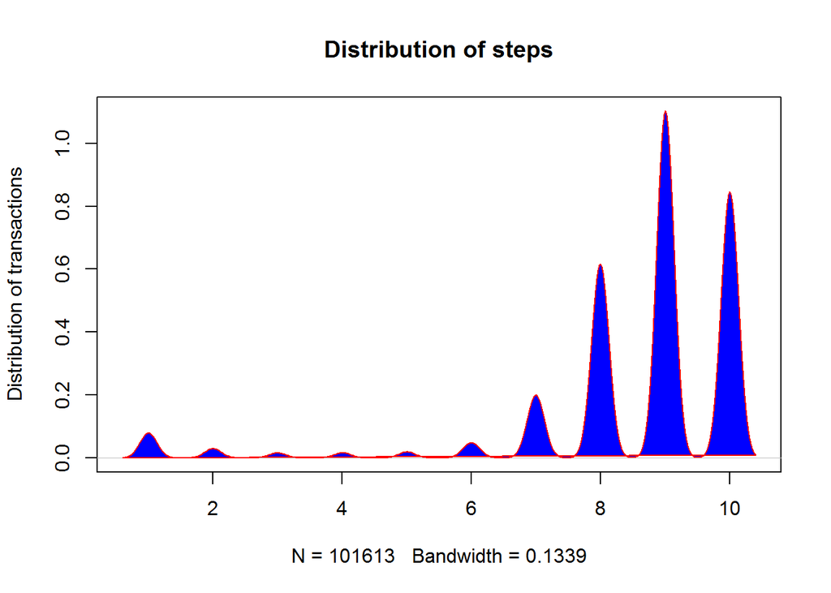

```r
#defining the function
density_plot<-function(data,var,main){
  plot(density(data[[var]]),ylab="Distribution of transactions",main=main)
  polygon(density(data[[var]]),col = "blue",border="red")
}
# calling the function
density_plot(df1,1,"Distribution of steps")
```

### Checking how fraud is distributed across the dataset

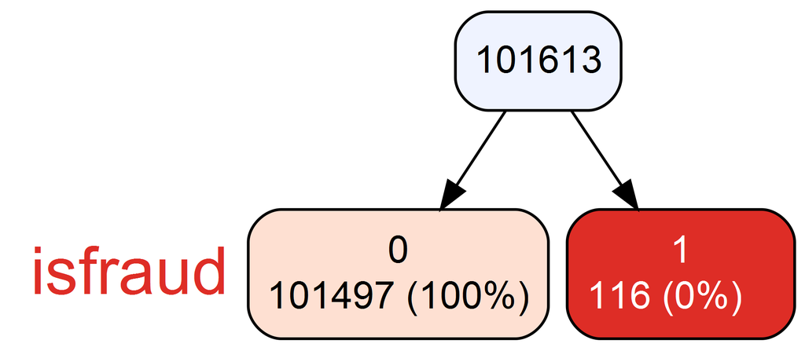

```r
#install.packages("vtree")
library(vtree)
isfraud <-df1$isfraud
vtree(isfraud,horiz=FALSE)
```

This can be attributed to the rear cases of fraud in financial institutions which normally happens once while involving a massive amount of money. ### Checking for is flagged fraud

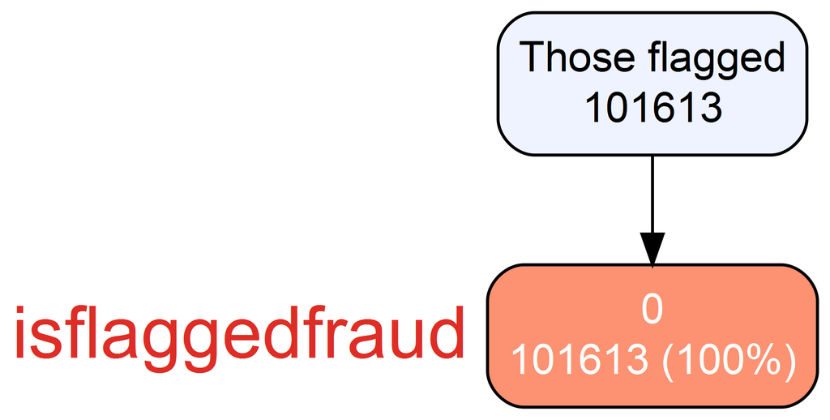

```r
isflaggedfraud<-df1$isflaggedfraud
vtree(isflaggedfraud,horiz=FALSE, title="Those flagged")
```

We have discovered the is flagged fraud variable is redundant since it has zero values only and yet its a target variable.

### Checking for the type of payments

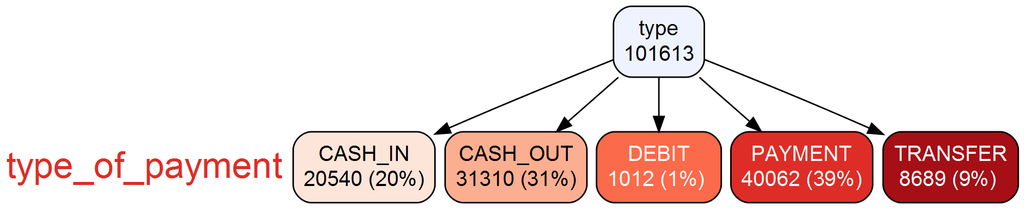

```r
#install.packages("vtree")
library(vtree)
type_of_payment <-df1$type

vtree(type_of_payment,horiz=FALSE, title="type")
```

# Bivariate

### Checking for the type of payments that are involve in fraud transactions

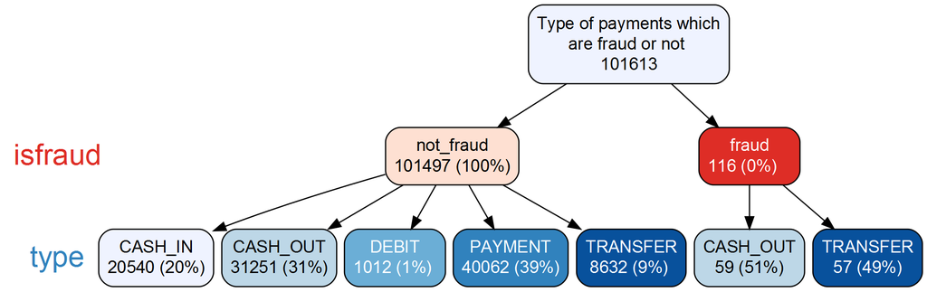

```r
vtree(df1,"isfraud type", title="Type of payments which are fraud or not ",
      labelnode=list(isfraud=c(not_fraud ="0",fraud ="1")),horiz=FALSE)
```

A total of 116 fraud transactions cases are happening during cash outs at 51% which represent 59 cases where there is a direct cash payment and also during transfer at 49% representing 57 cases at this point it is where money are transferred from illegitimate account to a legitimate one before exchanging hands.

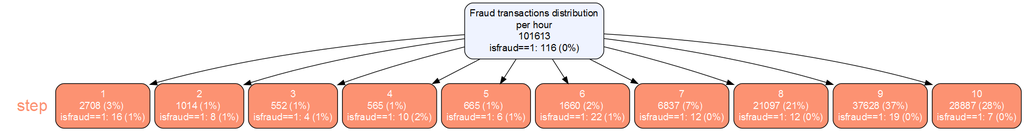

```r
vtree(df1,summary="isfraud==1","step",title="Fraud transactions distribution per hour",horiz=FALSE)
```

Most of the fraudulent transactions happened at the 6th hour the number being 22 followed by the 9th hour with 19 and the 1st hour by 16 fraudulent transactions .

```r
library(gridExtra)
```

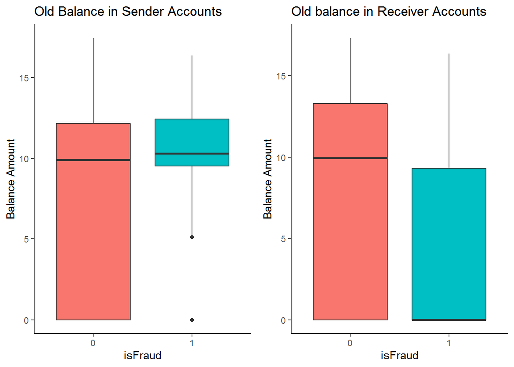

```r
library(grid)
library(tidyverse)
p1<- ggplot(data = df1, aes(x = factor(isfraud) ,y = log1p(oldbalanceorg), fill = factor(isfraud))) + geom_boxplot(show.legend = FALSE) +labs(title= 'Old Balance in Sender Accounts' , x = 'isFraud', y='Balance Amount') +  theme_classic()

p2 <- ggplot(data = df1, aes(x = factor(isfraud) ,y = log1p(oldbalancedest), fill = factor(isfraud))) + geom_boxplot(show.legend = FALSE) +labs(title= 'Old balance in Receiver Accounts' , x = 'isFraud',y='Balance Amount') +  theme_classic()

grid.arrange(p1, p2, nrow = 1)
```

In the majority of fraud transactions, the Old balance of the Origin account is higher than the Old balance in Destination accounts.

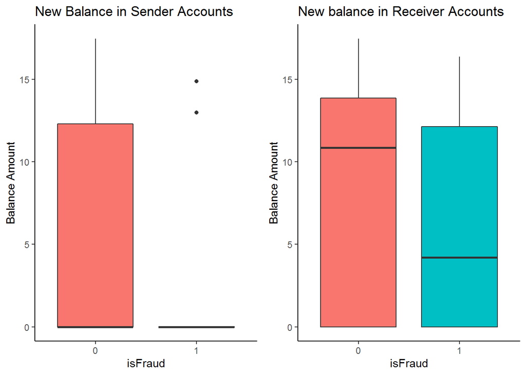

```r
plot1<- ggplot(data = df1, aes(x = factor(isfraud) ,y = log1p(newbalanceorig), fill = factor(isfraud))) + geom_boxplot(show.legend = FALSE) +labs(title= 'New Balance in Sender Accounts' , x = 'isFraud', y='Balance Amount') +  theme_classic()

plot2 <- ggplot(data = df1, aes(x = factor(isfraud) ,y = log1p(newbalancedest), fill = factor(isfraud))) + geom_boxplot(show.legend = FALSE) +labs(title= 'New balance in Receiver Accounts' , x = 'isFraud',y='Balance Amount') +  theme_classic()

grid.arrange(plot1, plot2, nrow = 1)
```

The new balance in the senders account of those involve in fraudulent transaction is very low compared to the new balance in the receiver account indicating that a massive amount of money has been transferred from one account to the other.

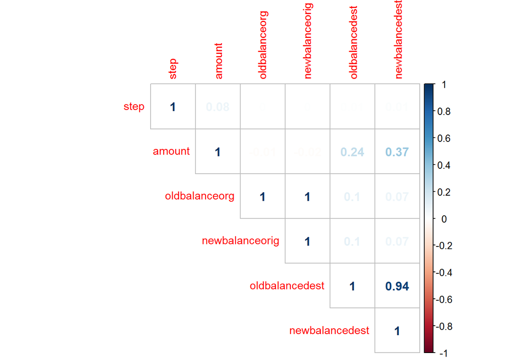

```r
# Checking for correlation

corrplot(cor(numcols), type= 'upper', method = 'number', tl.cex = 0.9)
```

1. The origin old balance and origin new balance have perfect positive correlation.

2. The destination old balance and destination new balance have very high positive correlation.

# Feature engineering

To perform our feature engineering we have to consider the following:

*The data is heavily imbalanced for each target class. We should consider sampling methods, like undersampling, to reduce model bias*

*We can filter our transaction types to include only CASH_OUT and TRANSFER types since these are the only transaction types with fraudulent cases*

*Fraudulent transactions tend to be of smaller amounts* *Fraudulent transactions tend to occur from 12am-9am*

## Feature Engineering and Data Cleaning

Check to see if transactions where the transaction Amount is greater than the balance available in the Origin account occur

```r
library(data.table)
head(df1[(df1$amount > df1$oldbalanceorg)& (df1$newbalancedest > df1$oldbalancedest), c("amount","oldbalanceorg", "newbalanceorig", "oldbalancedest", "newbalancedest", "isfraud")], 10)
```

```
##        amount oldbalanceorg newbalanceorig oldbalancedest newbalancedest
## 11    9644.94       4465.00              0          10845      157982.12
## 16  229133.94      15325.00              0           5083       51513.44
## 25  311685.89      10835.00              0           6267     2719172.89
## 49    5346.89          0.00              0         652637     6453430.91
## 73   94253.33      25203.05              0          99773      965870.05
## 82   78766.03          0.00              0         103772      277515.05
## 84  125872.53          0.00              0         348512     3420103.09
## 85  379856.23          0.00              0         900180    19200000.00
## 86 1505626.01          0.00              0          29031     5515763.34
## 89  761507.39          0.00              0        1280036    19200000.00
##    isfraud
## 11       0
## 16       0
## 25       0
## 49       0
## 73       0
## 82       0
## 84       0
## 85       0
## 86       0
## 89       0
```

#### Filter data

As noted earlier, we will filter our data by type to include only CASH_OUT and TRANSFER, we can also drop nameOrig and nameDest, as there are too many unique levels to create dummy variables.

```r
 # Filtering transactions and drop irrelevant features
df2<-df1 %>%
  select( -one_of('step','nameorig', 'namedest', 'isflaggedfraud')) %>%
  filter(type %in% c('CASH_OUT','TRANSFER'))
```

```r
head(df2)
```

```
##       type   amount oldbalanceorg newbalanceorig oldbalancedest newbalancedest
## 1 TRANSFER    181.0        181.00              0              0           0.00
## 2 CASH_OUT    181.0        181.00              0          21182           0.00
## 3 CASH_OUT 229133.9      15325.00              0           5083       51513.44
## 4 TRANSFER 215310.3        705.00              0          22425           0.00
## 5 TRANSFER 311685.9      10835.00              0           6267     2719172.89
## 6 CASH_OUT 110414.7      26845.41              0         288800        2415.16
##   isfraud
## 1       1
## 2       1
## 3       0
## 4       0
## 5       0
## 6       0
```

All the fraud transactions occur in CASH_OUT and TRANSFER type, so we drop other types and nameOrig, nameDest, and isFlaggedFraud are not useful so we drop them.

## Encoding Dummy variables for transaction type Since transaction type is categorical, we need to create dummy variables so the data is numerical

```r
#install.packages("fastDummies")
library(fastDummies)

df2<- dummy_cols(df2)

df2$isfraud <- as.factor(df2$isfraud)
df2 <- df2[,-1]
df2<-as.data.frame(df2)
```

# splitting the data into Train and Test Data

From the exploratory data analysis part we have know that fraud transactions are a rare event. Since fraudulent transactions only make up 116 of the data, duplicating fraudulent transactions in order to balance the data is not the best technique. It makes more sense to sample down non-event cases through undersampling.

```r
set.seed(12345)
train_id <- sample(seq_len(nrow(df2)), size = floor(0.7*nrow(df2)))

train <- df2[train_id,]
test <- df2[-train_id,]

table(train$isfraud)
```

```
##
##     0     1
## 27916    83
```

```r
table(test$isfraud)
```

```
##
##     0     1
## 11967    33
```

## Handling imbalance using undersampling

```r
#install.packages("unbalanced")
suppressMessages(library(unbalanced))
set.seed(12345)
prop.table(table(train$isfraud))
```

```
##
##           0           1
## 0.997035608 0.002964392
```

```r
inputs <- train[,-6]
target <- train[,6]

under_sam <- ubUnder(X = inputs, Y = target)
train_u <- cbind(under_sam$X, under_sam$Y)
train_u$isfraud <- train_u$`under_sam$Y`
train_u$`under_sam$Y` <- NULL

table(train_u$isfraud)
```

```
##
##  0  1
## 83 83
```

```r
prop.table(table(train_u$isfraud))
```

```
##
##   0   1
## 0.5 0.5
```

Using the undersampling method we are able to get a balanced training data set with 83 observations each. However, our test/ validation data will remain imbalanced,